# work number one

## 1 Предварительные настройки

#### 1.1. Импорт библиотек и установка параметров

```python
import serial # для работы с COM-портом
from serial.tools.list_ports import comports # для автоматического сканирования портов
import time
import matplotlib.pyplot as plt # построение графиков
import numpy as np # работа с массивами
import pandas as pd
import math
from scipy.optimize import curve_fit # подбор параметров наилучшей аппроксимации

# технические параметры (НЕ ИЗМЕНЯТЬ)
timeout = 1.0 # максимальное время ожидания
MAX_FAIL_COUNT = 3
baudrate = 250000 # скорость связи с контроллером
#Команды контроллера
READY = b'Ready\r\n'
EXIT = b'Exit\r\n'
```

#### 1.2. Подключение COM-порта

```python
ports = comports()
if len(ports):
    print("Найдены COM порты:", ports, ". Используем порт", ports[0])
    port = ports[0].name
else:
    print("ОШИБКА: COM порты не найдены. Проверьте подключения и повторите запуск блока.")
    port = None
```

```
Найдены COM порты: [<serial.tools.list_ports_common.ListPortInfo object at 0x00000158DBF59BD0>] . Используем порт COM4 - Устройство с последовательным интерфейсом USB (COM4)
```

#### 1.3 Параметры опыта

Внесите в массив ниже координаты катушек на вашей установке (в метрах). Первая катушка *должна* иметь координату (0.0).

```python
# Координаты катушек (в метрах)
X = np.array([
    0.0, # Координату 1-й катушку НЕ МЕНЯТЬ
    0.09,
    0.18,
    0.27,
    0.36,
    0.45,
    0.54,
    0.63,
    0.72,
    0.81,
])

Ncoils = X.size  # число катушек
print(f"Координаты N = {Ncoils} катушек: {X}")

# время измерения (секунды, только целое, по умолчанию 4)
measure_time = 4
MAX_VALUES = (measure_time + 1) * 2000 # не менять
print(f"Время измерения t_max = {measure_time} с, {MAX_VALUES} точек")
```

```
Координаты N = 10 катушек: [0.   0.09 0.18 0.27 0.36 0.45 0.54 0.63 0.72 0.81]
Время измерения t_max = 4 с, 10000 точек
```

## 2. Проведение опыта

Выберите и запустите блок кода ниже и следуйте появляющимся указаниям. Для повторного проведения опыта блок можно запустить заново.

```python
buffer = []
# подключение к контроллеру по последовательному порту
try:
    if port is None:
        raise RuntimeError
    ser = serial.Serial(port, baudrate, timeout=timeout)
except:
    print("Ошибка подключения. Проверьте кабели или попробуйте другое имя порта.")
    raise
else:
    print("Подключение успешно.")

# инициализация
line = ser.readline()
if line != b'':
    print("Линия не готова. Очищаем буфер. Если очистка идет слишком долго,\
    переподключите прибор и перезапустите программу")
    while line != b'':
        line = ser.readline()
        print('.', end='')
print("Приготовьте груз (магнит) и поместите его в трубу.")
print("Как будете готовы к запуску груза, нажмите Enter...")
input()
print("Запуск через")
print("5", end=' ')
time.sleep(1)
print("4", end=' ')
time.sleep(1)
print("3", end=' ')
time.sleep(1)
print("2", end=' ')
try:
    ser.write(str(measure_time).encode('ASCII')) # послать на контроллер команду запуска измрений
    time.sleep(1)
    print("1", end=' ')
    while line != READY:
        line = ser.readline() # дождаться готовности
    time.sleep(0.5) # 0.5 секунд для регистрации "пустого" сигнала
    print("Поехали!")
    FAIL_COUNT = 0
    while (line != EXIT) and (len(buffer) < MAX_VALUES):
        # считываем данные
        buffer.append(line)
        line = ser.readline()
        if line == b'': # если слишком часто считывается пустая строка, что-то пошло не так
            FAIL_COUNT += 1
        if FAIL_COUNT > MAX_FAIL_COUNT:
            raise
    if len(buffer) == 0:
        raise
except:
    print("Что-то пошло не так.\
          Поробуйте повторить опыт заново. Если не помогает:\
          переподключите прибор и перезапустите программу.")
else:
    print("Готово!")
finally:
    ser.close()

print("Собрано %d значений." % len(buffer))
```

```
Подключение успешно.
Приготовьте груз (магнит) и поместите его в трубу.
Как будете готовы к запуску груза, нажмите Enter...

Запуск через
5 4 3 2 1 Поехали!
Готово!
Собрано 6022 значений.
```

## 3. Подготовка сырых данных

Рассмотрите получающися график и убедитесь в том, что сигнал от катушек зарегистрирован корректно:

- На начальном участке зарегистрирован постоянный (фоновый) сигнал
- Сигнал не выходит за пределы окна измерений по времени
- Величина сигнала велика по сравнению с уровнем шумов (если сигнал слишком слаб -- переделайте опыт, увеличив чувствительность датчика)
- Сигнал не зашкаливает (если сигнал слишком силен -- переделайте опыт, уменьшив чувствительность датчика)

При необходимости переделайте опыт, повторно запустив блок `2`

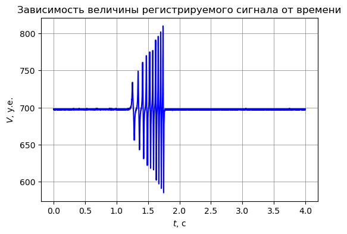

```python
data_ = []
for dot in buffer:
    try:
        time_voltage = dot.split(b' ')
        if len(time_voltage) == 2:
            data_.append([int(time_voltage[0]) / 1e6, int(time_voltage[1])])
    except ValueError:
        print("Предупреждение! Некорректные данные: ", dot)
        continue
d_time = np.array([d[0] for d in data_])
d_voltage = np.array([d[1] for d in data_])

# for testing
#d_time = np.linspace(0., measure_time, MAX_VALUES)
#d_voltage = np.sin((d_time*2)**2)

plt.figure(figsize=(6,4))
plt.plot(d_time, d_voltage, color='blue')
plt.title('Зависимость величины регистрируемого сигнала от времени')
plt.ylabel('$V$, у.е.')
plt.xlabel('$t$, с')
plt.grid(which='major', color = 'gray', linewidth=0.5)

plt.show()
```

## 4. Первичная обработка

#### 4.1 Определение уровня нуля и его погрешности

Автоматическое определение нулевого уровня по первым 200 точкам сигнала. По графику убедитесь, что на начальном участке действительно зарегистрирован нулевой сигнал, в противном случае переделайте опыт начиная с п. 2.

```
Среднее = 697.695, стд. отклонение = 0.460 (200 точек)
```

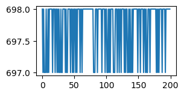

```python
Ndots = 200 # количество начальных точек

avg = np.mean(d_voltage)
semi_avg = np.mean(d_voltage[:Ndots]) # среднее по первым Ndots точкам (нулевой уровень)
D = np.std(d_voltage[:Ndots]) # стандартное отклонение
plt.figure(figsize=(3, 1.5))
plt.plot(d_voltage[:Ndots])
print("Среднее = %.3f, стд. отклонение = %.3f (%d точек)" % (semi_avg, D, Ndots))
```

#### 4.2 Выделение информативного участка

По умолчанию участок определяется автоматически по превышению порогового уровня сигнала.

Если участок вырезан неверно, попробуйте изменить параметры в начале блока:

- измените порог отклонения сигнала `threshold` (в единицах стандартного отклонения);
- Задайте вручную переменные `MANUAL_START` и `MANUAL_STOP` (в секундах).

**ВНИМАНИЕ!** Убедитесь, что максимумы и минимумы на графике ниже сменяют друг друга *последовательно* (не перемежаются). Если последовательность нарушена, **переделайте опыт** (возможно, с другим магнитом).

```python
# критерий отличия сигнала от нуля, в единицах станд. отклонения (по умолчанию - 5σ)
threshold = 5.0

# Для вырезания участка вручную установите отличными от нуля (в секундах)
MANUAL_START = 0
MANUAL_STOP = 0
```

```
Пороговое напряжение: 2.302 V
Автоматически выделен участок [1.22 с, 1.76 с] (точки [1910, 2716])
```

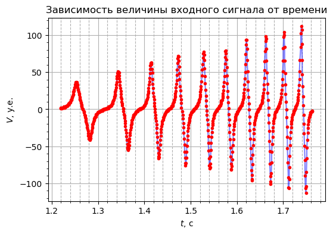

```python
idxs = np.where((abs(d_voltage - semi_avg) > threshold * D))
start = idxs[0][0]
stop = idxs[0][-1] + 1
print(f"Пороговое напряжение: {threshold * D:.3f} V")
print(f"Автоматически выделен участок [{d_time[start]:.2f} с, {d_time[stop - 1]:.2f} с] (точки [{start}, {stop}])")

if MANUAL_START > 0 and d_time[-1] > MANUAL_START:
    start = np.nonzero(d_time > MANUAL_START)[0][0] - 1
    print(f"ВНИМАНИЕ! Начало участка вручную установлено на {d_time[start]:.2f} с (точка {start})")
if MANUAL_STOP > 0 and d_time[-1] > MANUAL_STOP:
    stop = np.nonzero(d_time > MANUAL_STOP)[0][0] - 1
    print(f"ВНИМАНИЕ! Конец участка вручную установлен на {d_time[stop - 1]:.2f} с (точка {stop})")

s_time = d_time[start:stop]
s_voltage = d_voltage[start:stop] - semi_avg # отклонение напряжения от среднего ("нулевого") значения
N = stop - start # число точек

# график
plt.figure(figsize=(6, 4))
plt.plot(s_time, s_voltage, 'b-', alpha=0.5)
plt.plot(s_time, s_voltage, 'ro', markersize=3)
plt.title('Зависимость величины входного сигнала от времени')
plt.ylabel('$V$, у.е.')
plt.xlabel('$t$, с')
plt.minorticks_on()
plt.grid(which='major', linestyle='-')
plt.grid(which='minor', axis='x', linestyle='--')
```

## 5. Поиск локальных максимумов и минимумов

Первый экстремум принимается за начало отсчёта времени.

**ВНИМАНИЕ!** По результатам запуска блока проверьте, что экстремумы определны правильно:

- значения не пропущены;
- нет ложных экстремумов.

При обнаружении ошибки попробуйте изменить порог напряжения (`V_threshold`) или ширину "окна" (`t_width`) для поиска максимума и запустите блок ещё раз.

```python
V_threshold = 0.2 * np.max(s_voltage) # порог напряжения -- по умолчанию 20% от абсолютного максимума
t_width = 10 # ширина временного "окна" для поиска максимума (в точках) - по умолчанию 10
```

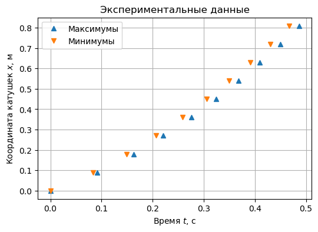

```
Времена максимумов, с: [0.   0.09 0.16 0.22 0.28 0.32 0.37 0.41 0.45 0.49]
Времена минимумов,  с: [0.   0.08 0.15 0.21 0.26 0.31 0.35 0.39 0.43 0.47]
```

```python
highs = []
lows = []
last_high = -1
last_low = -1
for i in range(t_width//2, N - t_width//2):
    V = s_voltage[i]
    if (V >= V_threshold
        and np.all(s_voltage[i - t_width//2: i + t_width//2] <= V)
        and i - last_high > t_width):
            highs.append(s_time[i])
            last_high = i
    if (V <= -V_threshold
        and np.all(s_voltage[i - t_width//2: i + t_width//2] >= V)
        and i - last_low > t_width):
            lows.append(s_time[i])
            last_low = i

# начало отсчёта времени -- первая точка
highs = np.array(highs - highs[0])
lows = np.array(lows - lows[0])

if False: #len(highs) != Ncoils or len(lows) != Ncoils:
    print("ОШИБКА! Число пиков не совпадает с числом катушек!\
    Измените критерии для поиска экстремумов или переделайте опыт")
else:
    plt.figure(figsize=(6,4))
    plt.plot(highs, X, '^', label='Максимумы')
    plt.plot(lows, X, 'v', label='Минимумы')
    plt.title("Экспериментальные данные")
    plt.ylabel("Координата катушек $x$, м")
    plt.xlabel("Время $t$, с")
    plt.legend()
    plt.grid()
    plt.show()

with np.printoptions(precision=2):
    print("Времена максимумов, с:", highs)
    print("Времена минимумов,  с:", lows)
```

## 6. Аппроксимация зависимости и определение ускорения

Теоретическая зависимость координаты груза от времени имеет вид $x(t) = v_0 t + a t^2 /2$ (момент $t=0$ соответствует первому пику).

Численным методом наименьших квадратов (метод *curve_fit*) подбираются оптимальные парметры $v_0$ и $a$, минимизирующие сумму квадратов отклонений экспериментальных точек от теоретической кривой.

Начальные скорости по максимуму и минимуму сигналов будут разными (так как соответствуют разным положениям магнита), однако ускорения должны быть одинаковы в пределах погрешности.

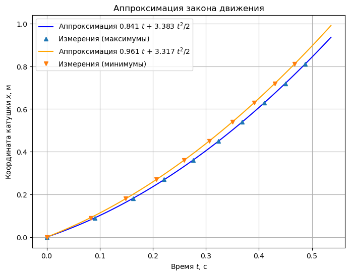

```
Ускорение по максимумам / по минимумам:
a_max = 3.383 ± 0.027, a_min = 3.317 ± 0.014 [м/с^2]
Среднее:
<a> = 3.350 ± 0.015 [м/с^2]
```

```python
motion_eq = lambda t, v0, a: v0 * t + 0.5 * a * t**2  # уравнение движения

coeffs_h, err_h = curve_fit(motion_eq, highs, X) # подбор по максимумам
coeffs_l, err_l = curve_fit(motion_eq, lows, X)  # подбор по минимумам

v1, a1 = coeffs_h
sa1 = np.sqrt(err_h[1][1])
v2, a2 = coeffs_l
sa2 = np.sqrt(err_l[1][1])

# график
plt.figure(figsize = (8, 6))
plt.title("Аппроксимация закона движения")
t = np.linspace(0., 1.1 * max(highs[-1], lows[-1]), 100)
plt.plot(t, motion_eq(t, *coeffs_h), color="blue",
         label="Аппроксимация %.3f $t$ + %.3f $t^2$/2" % (v1, a1))
plt.plot(highs, X, '^', label="Измерения (максимумы)")
plt.plot(t, motion_eq(t, *coeffs_l), color="orange",
         label="Аппроксимация %.3f $t$ + %.3f $t^2$/2" % (v2, a2))
plt.plot(lows, X, 'v', label="Измерения (минимумы)")
plt.legend()
plt.ylabel("Координата катушки $x$, м")
plt.xlabel("Время $t$, с")
plt.grid()
plt.show()

print("Ускорение по максимумам / по минимумам:")
print(f"a_max = {a1:.3f} ± {sa1:.3f}, a_min = {a2:.3f} ± {sa2:.3f} [м/с^2]")
print("Среднее:")
print(f"<a> = {0.5 * (a1 + a2):.3f} ± {0.5 * np.sqrt(sa1**2 + sa2**2):.3f} [м/с^2]")
```

## 7. Определение ускорения свободного падения и коэффициента трения

#### (блок запускается в конце работы по результатам серии опытов с разными углами)

Введите в соответствующие массивы в блоке ниже все углы наклона трубы и измеренные в опытах средние значения ускорения и их погрешности.

```python
# Углы (в градусах)
theta = np.array([
    12.6, 19.0, 25.4, 28.5, 34.4, 41.8, 47.3,
])

# Ускорения (м/с^2)
a = np.array([
    0.506, 1.597, 2.572, 3.070, 4.066, 5.063, 6.058,
])

# Погрешности углов (в градусах)
sigma_theta = np.array([
    0.5, 0.5, 0.5, 0.5, 0.5, 0.5, 0.5,
])

# Погрешности ускорений (м/с^2)
sigma_a = np.array([
    0.1, 0.1, 0.1, 0.1, 0.1, 0.1, 0.1,
])
```

```
µ = 0.173 +- 0.009 ; g = 9.599 +- 0.136 м^2/с
```

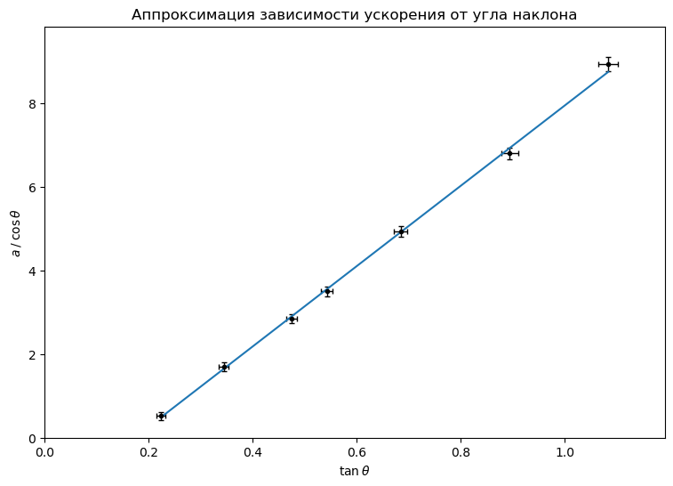

```python
# перевод углов в радианы
theta_rad = theta / 180 * np.pi
sigma_theta_rad = sigma_theta / 180 * np.pi

# замена переменных для линеаризации графика
ap = a / np.cos(theta_rad)
tn = np.tan(theta_rad)

# пересчёт погрешностей точек
sigma_cos = np.abs(np.sin(theta_rad)) * sigma_theta_rad
sigma_tan = sigma_theta_rad / np.cos(theta_rad)**2
sigma_ap = ap * np.sqrt((sigma_a / a)**2 + (sigma_cos / np.cos(theta_rad))**2)

f = lambda x, k, b: k * x + b

K, err = curve_fit(f, tn, ap, sigma=sigma_ap)

# результат аппроксимации
mu = -K[1]/K[0]
g = K[0]

# погрешности результа
sigma_g = np.sqrt(err[0][0])
sigma_mu = mu * np.sqrt(err[0][0] / g**2 + err[1][1] / K[1]**2)

print(f"µ = {mu:.3f} +- {sigma_mu:.3f} ; g = {g:.3f} +- {sigma_g:.3f} м^2/с")

plt.figure(figsize = (9, 6))
plt.title("Аппроксимация зависимости ускорения от угла наклона")
plt.errorbar(tn, ap, xerr=sigma_tan, yerr=sigma_ap, fmt='ko', ms=3, elinewidth=1, capsize=2)
plt.xlabel(r"$\tan \theta$")
plt.ylabel(r"$a\: /\: \cos \theta$")
plt.xlim(0, 1.1 * np.max(tn))
plt.ylim(0, 1.1 * np.max(ap))
plt.plot(tn, f(tn, *K), '-')
plt.show()
```